# UnsupervisedLearning_R4_Project1_carmpg

## Part two - Wine quality based on attributes

```python
com_df = pd.read_excel('Company.xlsx', engine = 'openpyxl')
```

```python
com_df.head()
```

|  | A | B | C | D | Quality |
| --- | --- | --- | --- | --- | --- |
| 0 | 47 | 27 | 45 | 108 | Quality A |
| 1 | 174 | 133 | 134 | 166 | Quality B |
| 2 | 159 | 163 | 135 | 131 | NaN |
| 3 | 61 | 23 | 3 | 44 | Quality A |
| 4 | 59 | 60 | 9 | 68 | Quality A |

```python
com_df['Quality'].value_counts()
```

```
Quality A    26
Quality B    17
Name: Quality, dtype: int64
```

```python
com_df.info()
```

```
<class 'pandas.core.frame.DataFrame'>
RangeIndex: 61 entries, 0 to 60
Data columns (total 5 columns):
 #   Column   Non-Null Count  Dtype
---  ------   --------------  -----
 0   A        61 non-null     int64
 1   B        61 non-null     int64
 2   C        61 non-null     int64
 3   D        61 non-null     int64
 4   Quality  43 non-null     object
dtypes: int64(4), object(1)
memory usage: 2.5+ KB
```

```python
com_df.Quality.isnull().sum()
```

```
18
```

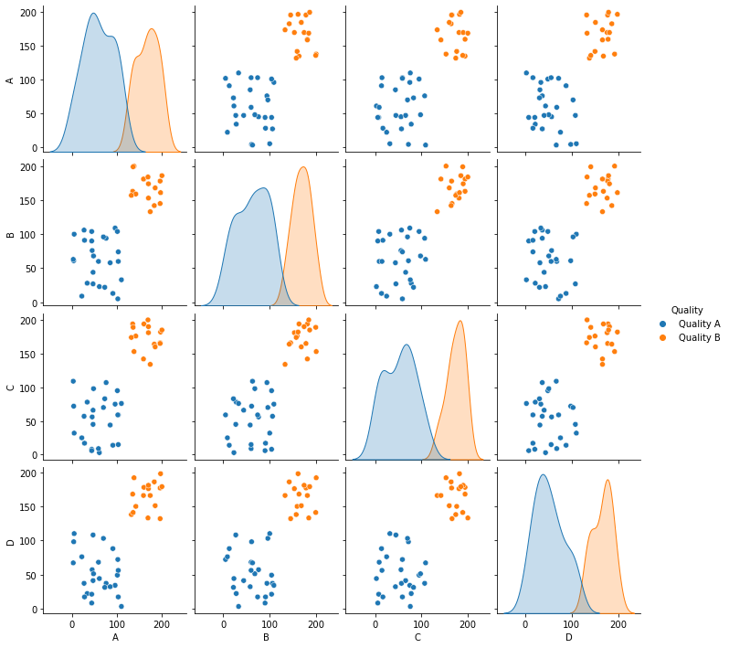

```python
sns.pairplot(com_df, hue = 'Quality')
```

##### In all of the attributes 2 clusters are very clearly visible. Let us build an SVM model and a KMeans model to predict classes based on the attributes.

##### First let us drop the missing values data

```python
wine_df = com_df.dropna()
wine_df.info()
```

```
<class 'pandas.core.frame.DataFrame'>
Int64Index: 43 entries, 0 to 56
Data columns (total 5 columns):
 #   Column   Non-Null Count  Dtype
---  ------   --------------  -----
 0   A        43 non-null     int64
 1   B        43 non-null     int64
 2   C        43 non-null     int64
 3   D        43 non-null     int64
 4   Quality  43 non-null     object
dtypes: int64(4), object(1)
memory usage: 2.0+ KB
```

```python
features = wine_df.drop('Quality', axis = 1)
target = wine_df.Quality
```

```python
X_train, X_test, y_train, y_test = train_test_split(features,target, test_size = 0.2, random_state = 10)
```

```python
from sklearn.svm import SVC

svc_model = SVC(C= .1, kernel='linear', gamma= 1)
svc_model.fit(X_train, y_train)

prediction = svc_model.predict(X_test)
```

```python
print(svc_model.score(X_train, y_train))
print(svc_model.score(X_test, y_test))
```

```
1.0
1.0
```

##### Our model has a 100% accurate prediction rate as the data provided could be divided into categories very easily. i.e, there is a very clear distinction between the attributes of Quality A and Quality B.

```python
from sklearn.metrics import accuracy_score, confusion_matrix
print("Confusion Matrix:\n",confusion_matrix(prediction,y_test))
```

```
Confusion Matrix:
 [[5 0]
 [0 4]]
```

```python
nan_data = com_df[com_df['Quality'].isna()].drop('Quality', axis = 1)
```

```python
nan_data.head()
```

|  | A | B | C | D |
| --- | --- | --- | --- | --- |
| 2 | 159 | 163 | 135 | 131 |
| 5 | 153 | 140 | 154 | 199 |
| 7 | 191 | 144 | 143 | 154 |
| 9 | 145 | 178 | 158 | 141 |
| 14 | 186 | 142 | 146 | 174 |

```python
missing_data = svc_model.predict(nan_data)
```

```python
nan_data['Quality'] = missing_data
```

```python
nan_data
```

|  | A | B | C | D | Quality |
| --- | --- | --- | --- | --- | --- |
| 2 | 159 | 163 | 135 | 131 | Quality B |
| 5 | 153 | 140 | 154 | 199 | Quality B |
| 7 | 191 | 144 | 143 | 154 | Quality B |
| 9 | 145 | 178 | 158 | 141 | Quality B |
| 14 | 186 | 142 | 146 | 174 | Quality B |
| 18 | 167 | 171 | 163 | 191 | Quality B |
| 23 | 171 | 185 | 181 | 183 | Quality B |
| 27 | 193 | 169 | 199 | 155 | Quality B |
| 29 | 29 | 49 | 6 | 35 | Quality A |
| 32 | 161 | 138 | 143 | 139 | Quality B |
| 35 | 181 | 147 | 174 | 130 | Quality B |
| 40 | 179 | 143 | 189 | 177 | Quality B |
| 46 | 197 | 173 | 165 | 197 | Quality B |
| 52 | 188 | 178 | 175 | 162 | Quality B |
| 57 | 137 | 182 | 165 | 199 | Quality B |
| 58 | 88 | 39 | 9 | 102 | Quality A |
| 59 | 180 | 157 | 192 | 198 | Quality B |
| 60 | 157 | 135 | 135 | 156 | Quality B |

```python
def impute_values_SVM(data):
    nan_data = data[data['Quality'].isna()].drop('Quality', axis = 1)
    missing_data = svc_model.predict(nan_data)
    nan_data['Quality'] = missing_data
    data = data.dropna()
    final_df = pd.concat([data, nan_data])
    return final_df.sort_index()
```

```python
impute_values_SVM(com_df)
```

|  | A | B | C | D | Quality |
| --- | --- | --- | --- | --- | --- |
| 0 | 47 | 27 | 45 | 108 | Quality A |
| 1 | 174 | 133 | 134 | 166 | Quality B |
| 2 | 159 | 163 | 135 | 131 | Quality B |
| 3 | 61 | 23 | 3 | 44 | Quality A |
| 4 | 59 | 60 | 9 | 68 | Quality A |
| ... | ... | ... | ... | ... | ... |
| 56 | 200 | 186 | 185 | 179 | Quality B |
| 57 | 137 | 182 | 165 | 199 | Quality B |
| 58 | 88 | 39 | 9 | 102 | Quality A |
| 59 | 180 | 157 | 192 | 198 | Quality B |
| 60 | 157 | 135 | 135 | 156 | Quality B |

61 rows × 5 columns

##### Just passing the dataset into the above function can impute any missing values that were failed to be noted by the company.

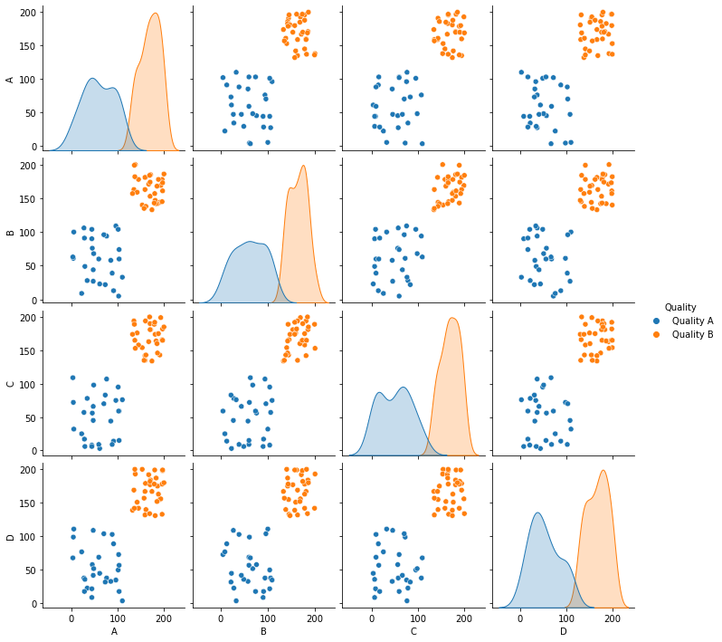

```python
sns.pairplot(impute_values_SVM(com_df), hue = 'Quality')
```

No overlap in the pairplots.

##### Now let us use K Means clustering to do the same.

##### We already know there are 2 clusters

```python
km_model_wine = KMeans(n_clusters=2, random_state=2)
```

```python
from sklearn.preprocessing import StandardScaler
sc=StandardScaler()
wine_z = sc.fit_transform(wine_df.drop('Quality', axis = 1)) # We need to use the same scaling factor when we predict missing values
```

```python
km_model_wine.fit(wine_z)
```

```
KMeans(n_clusters=2, random_state=2)
```

```python
wine_df_l = wine_df.copy()
wine_df_l['klabel'] = km_model_wine.labels_
```

```python
pd.crosstab(wine_df_l['Quality'], wine_df_l['klabel'])
```

| klabel Quality | 0 | 1 |
| --- | --- | --- |
| Quality A | 0 | 26 |
| Quality B | 17 | 0 |

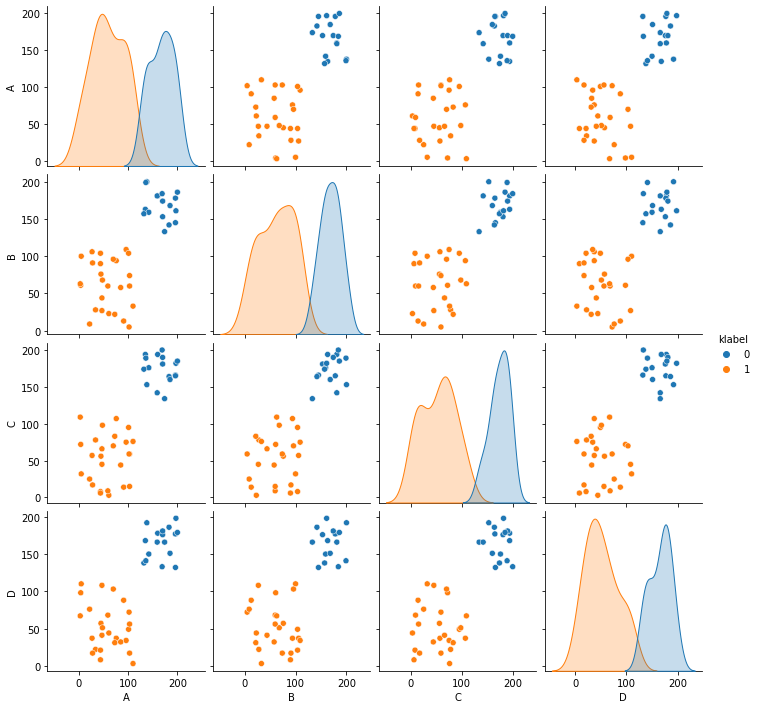

```python
sns.pairplot(wine_df_l, hue= 'klabel');
```

```python
def impute_values_KMeans(data):
    nan_data = data[data['Quality'].isna()].drop('Quality', axis = 1)
    nan_data_z = sc.transform(nan_data)
    nan_data['Quality'] = km_model_wine.predict(nan_data_z)
    nan_data.Quality.replace(0, 'Quality B', inplace = True)
    nan_data.Quality.replace(1, 'Quality A', inplace = True)
    data = data.dropna()
    final_df = pd.concat([data, nan_data])
    return final_df.sort_index()
```

##### Just pass the dataset with missing values into this function and it will return the dataset with imputed values based on prediction using K Means

```python
impute_values_KMeans(com_df)
```

|  | A | B | C | D | Quality |
| --- | --- | --- | --- | --- | --- |
| 0 | 47 | 27 | 45 | 108 | Quality A |
| 1 | 174 | 133 | 134 | 166 | Quality B |
| 2 | 159 | 163 | 135 | 131 | Quality B |
| 3 | 61 | 23 | 3 | 44 | Quality A |
| 4 | 59 | 60 | 9 | 68 | Quality A |
| ... | ... | ... | ... | ... | ... |
| 56 | 200 | 186 | 185 | 179 | Quality B |
| 57 | 137 | 182 | 165 | 199 | Quality B |
| 58 | 88 | 39 | 9 | 102 | Quality A |
| 59 | 180 | 157 | 192 | 198 | Quality B |
| 60 | 157 | 135 | 135 | 156 | Quality B |

61 rows × 5 columns

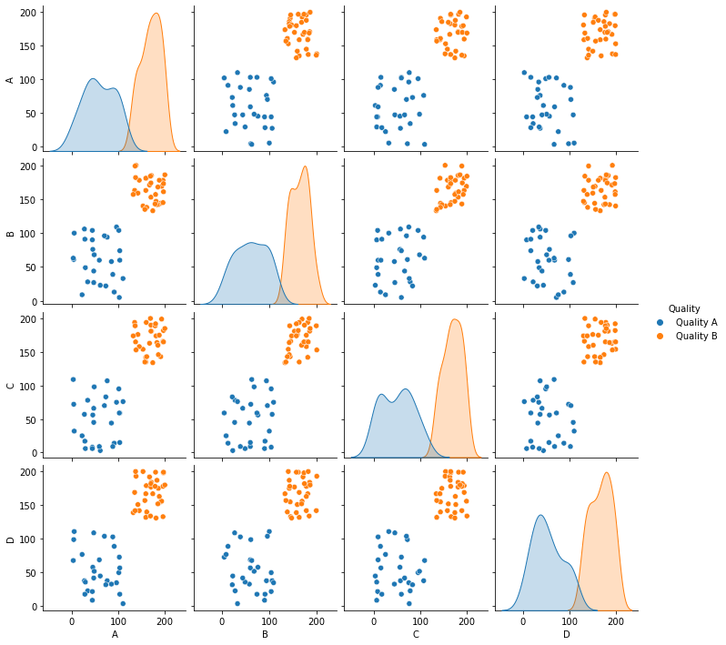

```python
sns.pairplot(impute_values_KMeans(com_df), hue = 'Quality')
```

##### The accuracy of both KMeans and SVM are the same. Supporting this are the pairplots drawn after predicting the missing values. There is absolutely no overlap in both the clusters.

Suggestion

##### In the future it would be helpful to have more data to work with. We have built a model using only 43 data points. Since we used K Means model it is advisable to scale our data but in this case, scaling can result in sampling errors as there are too few entries.

##### This is most likely to lead to overfitting of the model and may not be accurate in imputing the correct values into the missing data.

##### Since we have labeled data we can also use SVM (or some other supervised learning method) to train our model.